# Homework 2

Davide Berasi

2023-05-27

# Exercise 1: Estimating a log-odds with a normal prior

Suppose $Y$ has a binomial distribution with parameters $n$ and $p$, and we are interesting in the log-odds value $\theta=\operatorname{logit}(p) = \log(p/(1-p))$. Our prior for $\theta$ is that $\theta \sim N(\mu, \sigma)$ (parametrized as mean and standard deviation). It follows that the posterior density of $\theta$ is given, up to a proportional constant, by

$$g(\theta \vert y) \propto \frac{\exp(y\theta)}{(1+\exp(\theta))^n}
\exp\left[ -\frac{(\theta-\mu)^2}{2 \sigma^2} \right]$$

More concretely, suppose we are interested in learning about the probability that a special coin lands heads when tossed. A priori we believe that the coin is fair, so we assign $\theta$ an $N(0, .25)$ prior. We toss the coin $n=5$ times and obtain $y=5$ heads.

> - Using the prior density as a proposal density, design an Accept-Reject algorithm for sampling from the posterior distribution. Using simulated draws from your algorithm, approximate the probability that the coin is biased toward heads.

Let $q \sim N(0, 25)$ be our prior distribution and let $\bar{g}$ be the kernel of our target distribution, that is:
$$g(\theta \vert y) \propto \frac{\exp(y\theta)}{(1+\exp(\theta))^n}
\exp\left[ -\frac{(\theta-\mu)^2}{2 \sigma^2} \right] =: \bar{g}$$
In order to implement the accept-reject sampling algorithm we need a constant $M$ such that $\bar{g} \le Mq$. Since $y\le n$, we have that:
$$\bar{g} = \left(\frac{\exp(\theta)}{1+\exp(\theta)}\right)^y
\frac{1}{(1+\exp(\theta))^{n-y}} \exp\left[ -\frac{(\theta-\mu)^2}{2
\sigma^2} \right] \le 1 \cdot \exp\left[ -\frac{(\theta-\mu)^2}{2
\sigma^2} \right] = \sqrt{2\pi} \sigma \cdot q$$
Thus we can take $M = \sqrt{2\pi} \sigma \approx$ 0.6266571. Here is the implementation of the algorithm:

```r
g_bar <- function(t, y=5){
  return ( (exp(y*t -((t/0.25)**2) / 2 ) / (1+exp(t))**5) )
}

sampler_AR <- function(N){
  # returns N samples from our posterior distribution g.
  M <- sqrt(2*pi)*0.25
  samples <- rep(0, N)
  num_samples <- 0
  while (num_samples < N) {
    t <- rnorm(1, mean=0, sd=0.25)
    u <- runif(1)
    if (u * M*dnorm(t, mean=0, sd=0.25) < g_bar(t)){
      num_samples <- num_samples + 1
      samples[num_samples] <- t
    }
  }
  return(samples)
}
```

To visualize how good the algorithm is, we can compare the histogram of the samples with the posterior density.

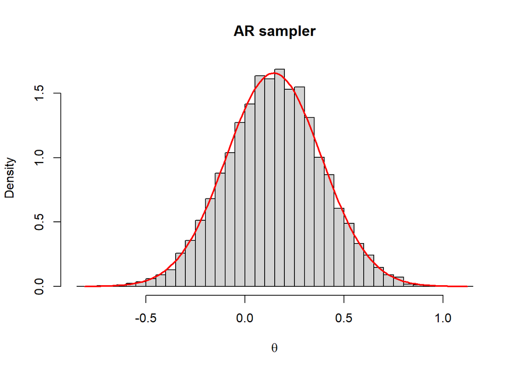

```r
N <- 10000
g_AR <-  sampler_AR(N)
hist(g_AR, main = 'AR sampler', xlab=TeX(r"($\theta$)"), breaks = 50, freq = FALSE)

# We approximate the normalizing constant by integrating.
norm_const <- integrate(function(t) g_bar(t,5),-Inf, Inf)$value
tt <- seq(min(g_AR), max(g_AR), 0.01)
g_tt <- g_bar(tt) / norm_const
lines(tt, g_tt, col='red', lwd=2)
```

Given $N$ samples $(\theta_1, \dots, \theta_N)$ from the posterior distribution, a good approximation of the probability that the coin is biased towards head is:

$$\mathbf{P}(\theta > 0 | Y=5) \approx
\frac{1}{n}\sum_{i=1}^{N}\mathbf{1}(\theta_i>0)$$

Using $N=$ 10^{4} samples from the accept-reject algorithm, our approximation is:

```r
sum(g_AR > 0) / N
```

```
## [1] 0.7313
```

We can also approximate a $95\%$ confidence interval for $\theta$ with $[g_{0.025}, g_{0.975}]$, where $g_{0.025}, g_{0.975}$ are the 0.025 and 0.975 quantile for our sample.

```r
quantile(g_AR, c(0.025, 0.975))
```

```
##       2.5%      97.5%
## -0.3271680  0.6181143
```

> - Using the prior density as a proposal density, simulate from the posterior distribution using a Sampling Importance Resampling (SIR) algorithm. Approximate the probability that the coin is biased toward heads.

The SIR sampler is very easy to implement:

```r
sampler_SIR <- function(N){
  # Sampling
  t <- rnorm(N, mean=0, sd=0.25)
  # Importance
  w <- g_bar(t) / dnorm(t, mean=0, sd=0.25)
  w <- w / sum(w)
  # Resampling
  t <- sample(t, size=N, replace=TRUE, prob=w)
return(t)
}
```

As before we can visualize how good the SIR algorithm is.

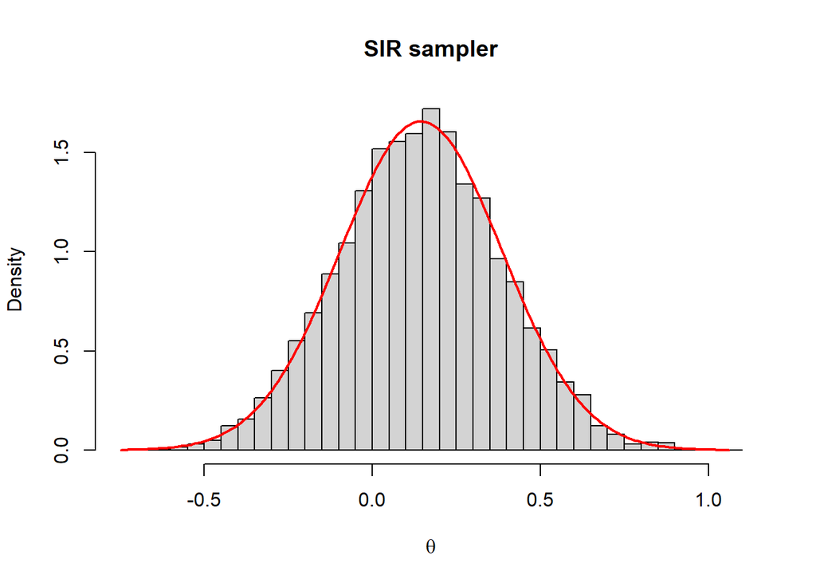

```r
g_SIR <-  sampler_AR(N)
hist(g_SIR, main = 'SIR sampler', xlab=TeX(r"($\theta$)"), breaks = 50, freq = FALSE)

tt <- seq(min(g_SIR), max(g_SIR), 0.01)
g_tt <- g_bar(tt) / norm_const
lines(tt, g_tt, col='red', lwd=2)
```

Using the SIR sampler, the approximation of the probability that the coin is biased towards head is:

```r
g_SIR <- sampler_SIR(N)
sum(g_SIR > 0) / N
```

```
## [1] 0.737
```

In this case the approximation for a $95\%$ confidence interval for $\theta$ is:

```r
quantile(g_SIR, c(0.025, 0.975))
```

```
##       2.5%      97.5%
## -0.3083006  0.5987065
```

> - Use a Laplace approximation to estimate the probability that the coin is biased toward heads.

In the Laplace approximation we approximate our posterior $g$ with the “best fitting” normal $\mathcal{N}(m, v)$. Its mean is the mode $m$ of $g$. We can compute it numerically.

```r
# To compute the maximum we can use the function optimize.
m <- optimize(g_bar, c(0, 0.5), maximum = TRUE)$maximum
m
```

```
## [1] 0.1449478
```

For the standard deviation $v$ we know that
$$-\frac{1}{v^2} = \left. \frac{d^2}{d\theta^2}\log(g(\theta))
\right\vert_{\theta=m} = - n \frac{\exp(m)}{(1+ \exp(m))^2} -
\frac{1}{\sigma^2}$$
Thus we can approximate it:

```r
d2_log_g <- -5*exp(m) / (1 + exp(m))^2 - 1/0.25^2
v <- sqrt(-1/d2_log_g)
v
```

```
## [1] 0.2408174
```

With Laplace approximation, the probability that the coin is biased towards head is:

```r
pnorm(0, mean=m, sd=v, lower.tail=FALSE)
```

```
## [1] 0.7263794
```

In this case the approximation for a $95\%$ confidence interval for $\theta$ is:

```r
qnorm(c(0.025, 0.975), mean=m, sd=v)
```

```
## [1] -0.3270456  0.6169412
```

# Exercise 2: Genetic linkage model

Suppose $197$ animals are distributed into four categories with the following frequencies

| Category | Frequency |
| --- | --- |
| 1 | 125 |
| 2 | 18 |
| 3 | 20 |
| 4 | 34 |

Assume that the probabilities of the four categories are given by the vector

$$\left( \frac{1}{2} + \frac{\theta}{4}, \frac{1}{4} (1 -
\theta), \frac{1}{4} (1 - \theta), \frac{\theta}{4} \right) \ ,$$

where $\theta$ is an unknown parameter between $0$ and $1$. If $\theta$ is assigned a uniform prior, then the posterior density of $\theta$ is given by

$$h(\theta \vert \text{data}) \propto \left( \frac{1}{2} +
\frac{\theta}{4} \right)^{125} \left( \frac{1}{4} (1 - \theta)
\right)^{18} \left( \frac{1}{4} (1 - \theta) \right)^{20} \left(
\frac{\theta}{4} \right)^{34} \ ,$$

where $0 < \theta < 1$.

> - If $\theta$ is transformed to the real-valued logit $\eta = \log(\theta/(1 - \theta))$, then calculate the posterior density of $\eta$.

The distribution of $\eta \vert \text{data}$ is $g(\eta \vert \text{data}) = h(\theta \vert \text{data}) \left\lvert \frac{d}{d\eta} \theta(\eta))\right\lvert$. Since
$$\theta(\eta) = \frac{\exp(\eta)}{1+\exp(\eta)} \hspace{1cm} \text{and}
\hspace{1cm} \left\lvert \frac{d}{d\eta} \theta(\eta)\right\lvert =
\frac{\exp(\eta)}{(1+\exp(\eta))^2}$$

the posterior of $\eta$ is

$$\begin{equation}
\begin{aligned}
g(\eta \vert \text{data}) & \propto \left( \frac{1}{2}
+\frac{\exp(\eta)}{4(1+\exp(\eta))} \right)^{125}
\left( \frac{1}{4} \left(1 - \frac{\exp(\eta)}{1+\exp(\eta)}\right)
\right)^{18}
\left( \frac{1}{4} \left(1 - \frac{\exp(\eta)}{1+\exp(\eta)}\right)
\right)^{20}
\left( \frac{\exp(\eta)}{4(1+\exp(\eta))} \right)^{34}
\frac{\exp(\eta)}{(1+\exp(\eta))^2} \\
& = \left( \frac{2 + 3\exp(\eta)}{4(1+\exp(\eta))} \right)^{125}
\left( \frac{1}{4(1+\exp(\eta))} \right)^{18}
\left( \frac{1}{4(1+\exp(\eta))} \right)^{20}
\left( \frac{\exp(\eta)}{4(1+\exp(\eta))} \right)^{34}
\frac{\exp(\eta)}{(1+\exp(\eta))^2} \\
& \propto
\frac{(2+3\exp(\eta))^{125}\exp(35\eta)}{(1+\exp(\eta))^{199}} =:
\bar{g}(\eta)
\end{aligned}
\end{equation}$$

We can plot it:

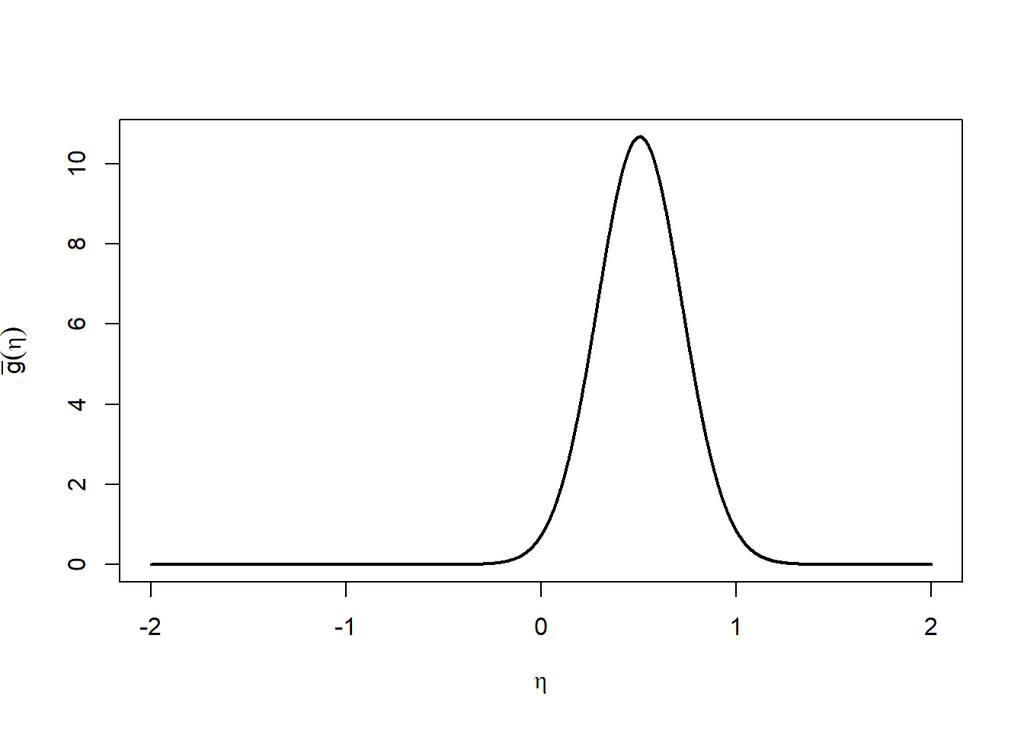

```r
# The kernel defined as above takes very small values. In order to avoid problems with the float precision, I multiply it by 10^91.
g_bar2 <- function(e){
log_num <- 125*log(2+3*exp(e))+35*e + 91*log(10)
log_den <- 197*log(4)+199*log(1+exp(e))
return(exp(log_num-log_den))
}

ee <- seq(-2, 2, 0.001)
plot(ee, g_bar2(ee), type='l', lwd=2, xlab=TeX(r"($\eta$)"), ylab=TeX(r"($\bar{g}(\eta)$)"))
```

> - Use a normal approximation to find a $95\%$ probability interval for $\eta$. Transform this interval to obtain a $95\%$ probability interval for the original parameter of interest $\theta$.

As in Exercise 1, a normal approximation is given by the Laplace approximation $\mathcal{N}(m, v)$. In this case the mean is

```r
m <- optimize(g_bar2, c(0, 1), maximum = TRUE)$maximum
m
```

```
## [1] 0.5066005
```

while for the standard deviation we compute the second derivative of $\log(g(\eta \vert \text{data}))$ symbolically and evaluate it in $m$

```r
log_g = expression(125*log(2+3*exp(eta)) + 35*eta - 199*log(1+exp(eta)))
d2_log_g <- D(D(log_g, 'eta'), 'eta')
eta <- m
v <- sqrt(-1 / eval(d2_log_g))  # sd of of our normal approximation
v
```

```
## [1] 0.2175282
```

Thus, the approximation of the $95\%$ confidence interval for $\eta$ is

```r
I_eta <- qnorm(c(0.025, 0.975), mean=m, sd=v)
I_eta
```

```
## [1] 0.08025304 0.93294791
```

Since the transformation $\eta = \eta(\theta)$ is monotonically increasing, if $I_{\eta}$ is the CI for $\eta$, then the corresponding CI for $\theta$ $I_{\eta} = \eta^{-1}(I)$.

```r
eta_inv <- function(eta) exp(eta) / (1 + exp(eta))
I_theta <- eta_inv(I_eta)
I_theta
```

```
## [1] 0.5200525 0.7176730
```

> - Design an Accept-Reject sampling algorithm for simulating from the posterior density $\eta$. Use a $t$ proposal density using a small number of degrees of freedom and mean and scale parameters given by the normal approximation.

We can use a student-t with 3 degrees of freedom because it has finite mean and variance.

Then, we need $M$ such that $\bar{g} \le Mq$ or equivalently $M \ge \frac{\bar{g}}{q}$. So we can take $M = \max_{\eta} \frac{\bar{g}}{q}$.

```r
library(mnormt)
M <- optimize(function(e) g_bar2(e) / dmt(e, mean=m, S=v, df=3), interval = c(0, 1), maximum = TRUE)$objective
M
```

```
## [1] 13.54832
```

We can plot the two densities to verify that $\bar{g}$ is below $M\cdot q$.

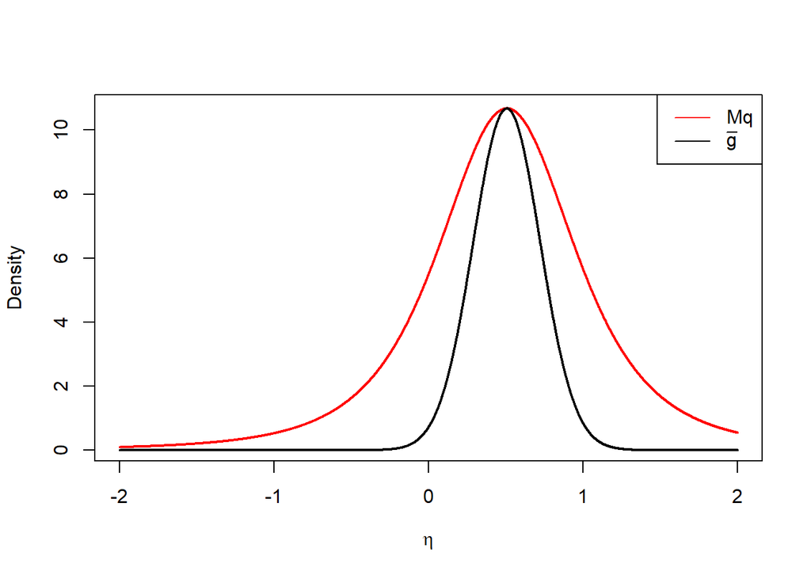

```r
plot(ee, M*dmt(ee, mean=m, S=v, df=3), type='l', col='red', lwd=2, xlab=TeX(r"($\eta$)"), ylab = 'Density')
lines(ee, g_bar2(ee), lwd=2)
legend(x='topright', legend=c(TeX(r"($Mq$)"), TeX(r"($\bar{g}$)")), lty=1, col=c("red", "black"))
```

```r
sampler_AR2 <- function(N){
  # returns N samples from our posterior distribution (g).
  samples <- rep(0, N)
  num_samples <- 0
  while (num_samples < N) {
    e <- rmt(1, mean=m, S=v, df=3)
    u <- runif(1)
    if (u * M*dmt(e, mean=m, S=v, df=3) < g_bar2(e)){
      num_samples <- num_samples + 1
      samples[num_samples] <- e
    }
  }
  return(samples)
}
```

> - Compare the results of the two procedures.

We can have a visual comparison of the two procedure by comparing the plots of the density of the normal, the histogram of a lot of samples from the AR algorithm and the density of the true distribution.

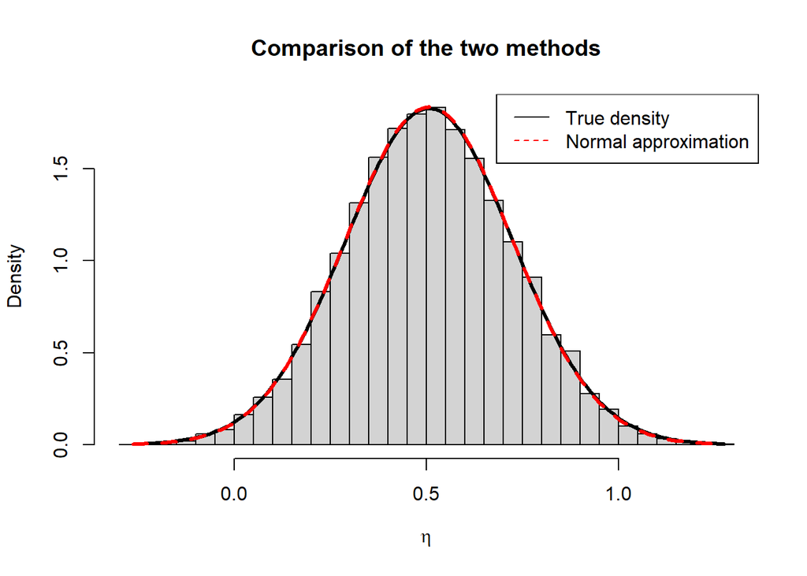

```r
N <- 10000
g_AR2 <-  sampler_AR2(N)
hist(g_AR2, main = 'Comparison of the two methods', xlab = expression(eta), breaks = 50, freq = FALSE)

ee <- seq(min(g_AR2), max(g_AR2), 0.01)
g_ee <- g_bar2(ee) / integrate(function(e) g_bar2(e),-3, 3)$value
lines(ee, g_ee, col=, lwd=3)
lines(ee, dnorm(ee, mean=m, sd=v), lty='dashed', col='red', lwd=3)

legend(x='topright', legend=c("True density", "Normal approximation"), lty=1:2, col=c("black", "red"))
```

We can see that both methods are very good approximations.

# Exercise 3: Poisson Regression

Consider an experiment involving subjects reporting one stressful event. The collected data $y_{1}, \cdots, y_{18}$ where $y_{i}$ is the number of events recalled $i$ months before the interview. Suppose $y_i$ is Poisson distributed with mean $\lambda_i$, where the $\lambda_i$s satisfy the loglinear regression model

$$\log \lambda_i = \beta_0 +\beta_1 i \ .$$

The data are shown in the following table

| x | y |
| --- | --- |
| 1 | 15 |
| 2 | 11 |
| 3 | 14 |
| 4 | 17 |
| 5 | 5 |
| 6 | 11 |
| 7 | 10 |
| 8 | 4 |
| 9 | 8 |
| 10 | 10 |
| 11 | 7 |
| 12 | 9 |
| 13 | 11 |
| 14 | 3 |
| 15 | 6 |
| 16 | 1 |
| 17 | 1 |
| 18 | 4 |

If $(\beta_0, \beta_1)$ is assigned a uniform prior, then the log of the posterior density is given, up to an additive constant, by

$$\log(g(\beta_0, \beta_1 \vert data)) \propto \sum_{i=1}^{18} \left[
y_i (\beta_0 + \beta_1 i ) - \exp(\beta_0 + \beta_1 i) \right]$$

> - Write an R function to compute the log of the posterior density of $(\beta_0, \beta_1)$.

```r
log_post <- function(beta){
  i <- 1:18
return(sum(y*(beta[1] + beta[2]*i) - exp(beta[1] + beta[2]*i)))
}
```

> - Suppose we are interested in estimating the posterior mean and standard deviation for the slope $\beta_1$. Approximate these moments by a normal approximation about the posterior mode.

Since we are approximating the bivariate posterior with a normal $\mathcal{N}(m = (m_0, m_1), V)$, then the marginal of $\beta_1$ is a normal of mean $m_1$ and variance $V[2, 2]$.

The function `optim` that we use to compute the mode and the hessian of the posterior needs a starting point. In order to get one, we can fit a line to the data, in the log scale.

```r
library(stats)  # To fit the line to the data.

fitted_line <- glm(log(y) ~ x)
beta_start <- fitted_line[1]$coefficients
normal_param <- optim(par = beta_start, fn = log_post, hessian=TRUE, control=list(fnscale=-1))
mode_beta <- normal_param$par
V <- - solve(normal_param$hessian) # Covariance matrix of the posterior.

mean_beta1_norm <- mode_beta[2]
sd_beta1_norm <- sqrt(V[2, 2])
```

For the normal approximation of $\beta_1$, the mean is -0.0837361 and standard deviation is 0.0167991.

> - Use a multivariate $t$ proposal density and the SIR algorithm to simulate 1000 draws from the posterior density. Use this sample to estimate the posterior mean and standard deviation of the slope $\beta_1$.

The SIR algorithm for the bivariate case is very easy to implement.

```r
log_post_vec <- function(beta){
  # Same as log_post, but takes a matrix as input.
  sum_1_18 <- 0
  for (i in 1:18) {
    sum_1_18 <- sum_1_18 + y[i]*(beta[,1] + beta[,2]*i) - exp(beta[,1] + beta[,2]*i)
  }
return(sum_1_18)
}
sampler_SIR3 <- function(N){
  # Sampling
  beta <- rmt(N, mean=mode_beta, S=V, df=3)
  # Importance
  # To avoid problems with float precision I subtract 174 from log_post_vec(beta).
  w <- exp(log_post_vec(beta) - 174 - log(dmt(beta, mean=mode_beta, S=V, df=3)))
  w <- w / sum(w)
  # Resampling
  idx <- sample(1:N, size=N, replace=TRUE, prob=w)
return(beta[idx,])
}
```

We can use the sampler to estimate the posterior mean and standard deviation of $\beta_1$.

```r
g_SIR3 <- sampler_SIR3(1000)
mean_beta1_SIR <- mean(g_SIR3[,2])
sd_beta1_SIR <- sd(g_SIR3[,2])
```

The SIR approximation for the mean is -0.084934 and for the standard deviation is 0.0159358.

> - Compare your estimates with the estimates using the normal approximation.

We can compute the difference between the parameters obtained with the two approximations.

```r
mean_beta1_SIR - mean_beta1_norm
```

```
##            x
## -0.001197922
```

```r
sd_beta1_SIR - sd_beta1_norm
```

```
## [1] -0.0008632505
```

The two approximations are very close.

# Exercise 4: Variance components model

Consider the data concerning batch-to-batch variation in yields of dyestuff. The following data arise from a balanced experiment whereby the total product yield was determined for five samples from each of six randomly chosen batches of raw material.

|  | S1 | S2 | S3 | S4 | S5 |
| --- | --- | --- | --- | --- | --- |
| 1 | 1545 | 1440 | 1440 | 1520 | 1580 |
| 2 | 1540 | 1555 | 1490 | 1560 | 1495 |
| 3 | 1595 | 1550 | 1605 | 1510 | 1560 |
| 4 | 1445 | 1440 | 1595 | 1465 | 1545 |
| 5 | 1595 | 1630 | 1515 | 1635 | 1625 |
| 6 | 1520 | 1455 | 1450 | 1480 | 1445 |

Let $y_{ij}$ denote the $j$th observation in batch $i$. To determine the relative importance of between-batch variation versus sampling variation, the following multilevel model is applied ($N$ denotes the number of batches and $n$ denotes the number of observations per batch).

- $y_{ij} \sim N(\mu + b_i, \sigma_y)$, $i=1,\ldots,N$, $j=1,\ldots,n$.
- $b_i \sim N(0, \sigma_b)$, $i=1,\ldots,N$.
- $(\sigma^2_y, \sigma^2_b)$ is assigned a uniform prior.

In this situation, the focus is on the marginal posterior distribution of the variance components. It is possible to analytically integrate out the random effects $b_i$s, resulting in the marginal posterior density of $(\mu, \sigma^2_y, \sigma^2_b)$ given, up to a proportionally constant, by

$$\prod_{i=1}^N \left[ \phi\left( \bar{y}_i \vert \mu,
\sqrt{\sigma^2_y/n + \sigma^2_b} \right) f_G\left( S_i \vert (n-1)/2,
1/(2 \sigma^2_y) \right) \right] \ ,$$

where $\hat{y}_i$ and $S_i$ are respectively the mean yield and the “within sum of squares” of the $i$th batch, $\phi\left(y \vert \mu,\sigma\right)$ is the normal density of mean $\mu$ and standard deviation $\sigma$, and $f_G(y \vert a,b)$ is the gamma density proportional to $y^{a-1} \exp( - b y)$.

> - Write an R function for the log of the posterior density with parametrization $\theta = (\mu, \log\sigma_y, \log\sigma_b)$.

We have to consider the transformation
$$h : (\mu, \sigma^2_y, \sigma^2_b) \to \left(\mu,
\frac{1}{2}\log(\sigma^2_y), \frac{1}{2}\log(\sigma^2_b) \right) = (\mu,
\log(\sigma_y), \log(\sigma_b)) =: \theta$$
that has inverse
$$h^{-1} (\mu, \log(\sigma_y), \log(\sigma_b)) \to \left(\mu,
e^{2\log(\sigma_y)}, e^{2\log(\sigma_b)}\right)$$

The determinant of the Jacobian is
$$|J| =
\begin{vmatrix}
1 & 0 & 0 \\
0 & \frac{1}{2\sigma^2_y} & 0 \\
0 & 0 & \frac{1}{2\sigma^2_b}
\end{vmatrix}
= \frac{1}{4\sigma^2_y\sigma^2_b}$$
so $|J^{-1}| = 4\sigma^2_y\sigma^2_b$. The log of the posterior density of theta, up to an additive constant, is

$$\begin{align}
\log\left(g(\theta \vert y)\right) & \propto \sum_{i=1}^N
\log\left(\phi\left( \bar{y}_i \vert \mu, \sqrt{e^{2\log(\sigma_y)}/n
+ e^{2\log(\sigma_y)}} \right)\right) +
\log\left(f_G\left( S_i \vert (n-1)/2, 1/(2 e^{2\log(\sigma_y)})
\right)\right) +
\log\left(4 e^{2\log(\sigma_y)}e^{2\log(\sigma_b)} \right ) \\
& \propto \sum_{i=1}^N
-\log(\sigma_y)
-\frac{1}{2}\frac{(\bar{y}_i-\mu)^2}{e^{2\log(\sigma_y)}/n +
e^{2\log(\sigma_y)}} +
\frac{n-3}{2}\log(S_i) - \frac{S_i}{2e^{2\log(\sigma_y)}} +
2\log(\sigma_y) + 2\log(\sigma_b)
\end{align}$$

Before writing the R function for the log of the posterior density of $\theta$ I compute $\bar{y}_i$ and $S_i$.

```r
y_bar <- rowMeans(y)
S <- rowSums((y - y_bar)^2)
```

Now we can write the function

```r
log_post_theta <- function(theta, y_bar_=y_bar, S_=S){
  mu <- theta[1]
  sig2y <- exp(2*theta[2])
  sig2b <- exp(2* theta[3])

  log_phi <- dnorm(y_bar_, mu, sqrt(sig2y/5+sig2b),log=TRUE)
  log_fG <- dgamma(S_, shape = 2, rate = 1/(2*sig2y), log=TRUE)
  return( sum(log_phi + log_fG) + log(4*sig2y*sig2b) )
}
```

> - Using a normal approximation, to this aim, find the posterior mode of $\theta$ using a numerical method and try the following alternative starting values:
>   - $\theta=(1500, 3, 3)$
>   - $\theta=(1500, 1, 1)$
>   - $\theta=(1500, 10, 10)$

> and assess the sensitivity of the numerical method to the starting value.

As always, we can compute the posterior mode using the function `optim`.

```r
laplace3 <- optim(c(1500, 3, 3), log_post_theta, hessian = TRUE, control = list(fnscale=-1))
laplace1 <- optim(c(1500, 1, 1), log_post_theta, hessian = TRUE, control = list(fnscale=-1))
laplace10<- optim(c(1500,10,10), log_post_theta, hessian = TRUE, control = list(fnscale=-1))

mode <- rbind(laplace3$par, laplace1$par, laplace10$par)
rownames(mode) <- c("(1500,  3,  3) ", "(1500,  1,  1) ", "(1500, 10, 10) " )
colnames(mode) <- c("mu  ", " log(sigma_y)", " log(sigma_b)")

print(mode)
```

```
##                     mu    log(sigma_y)  log(sigma_b)
## (1500,  3,  3)  1527.504      3.936728      3.933113
## (1500,  1,  1)  1527.599      3.936642      3.932815
## (1500, 10, 10)  1527.490      3.936826      3.932787
```

An estimate of the sensitivity to the starting value is the following ratio:

```r
d_g <- norm(laplace3$par - laplace1$par, type='2')
d_theta <- norm(c(1500, 3, 3)- c(1500, 1, 1), type='2')
sensitivity <- d_g / d_theta
sensitivity
```

```
## [1] 0.03326983
```

> - Use the normal approximation to find $90\%$ interval estimates for the log of the standard deviation $\log\sigma_y$, $\log\sigma_b$.

We can use the estimate of the mode and the hessian obtained with the first starting value. Thus, the parameters of our normal are:

```r
m <- laplace3$par
V <- - solve(laplace3$hessian)
```

So an estimate of the $90\%$ confidence interval for $\log\sigma_y$ is

```r
I_log_sigy <- qnorm(c(0.05, 0.95), mean=m[2], sd=sqrt(V[2, 2]))
I_log_sigy
```

```
## [1] 3.693275 4.180181
```

while for $\log\sigma_b$ is

```r
I_log_sigb <- qnorm(c(0.05, 0.95), mean=m[3], sd=sqrt(V[3, 3]))
I_log_sigb
```

```
## [1] 3.241286 4.624940
```

> - Using the results from the previous point find $90\%$ interval estimates for the variance components $\sigma_y^2$, $\sigma_b^2$.

If $\sigma>0$, then $a \le \log(\sigma) \le b \iff e^{2a} \le \sigma^2 \le e^{2b}$. So the confidence interval for $\sigma_y^2$ is

```r
exp(2 * I_log_sigy)
```

```
## [1] 1614.128 4274.242
```

while for $\sigma_b^2$ is

```r
exp(2 * I_log_sigb)
```

```
## [1]   653.6504 10403.3071
```